# Lecture 4: Binned scatter plots and multivariate regression

Jack Blundell

PUBLPOL 330D Applied Econometrics for Public Policy, Winter 2020

- My email: jackblundell@stanford.edu
- My office hours: 8.30 - 10.30am every Thursday at Econ 350 (Landau building)
- Section (further office hours): 2.30 - 3.20pm (Bass B312)

## 1. Reading Stata regression output

Lets say we run the following regression in Stata:  
*y* = *β*<sub>0</sub> + *β*<sub>1</sub>*x* + *β*<sub>2</sub>*z* + *ϵ*

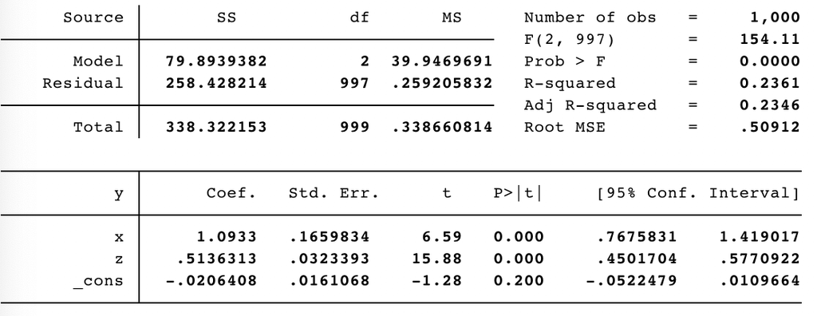

Regression output

- The `Coef.` column gives each estimated parameter, with `_cons` giving intercept *β*<sub>0</sub>
- Standard errors are given in `Std. Err.`
- The remaining columns are p-values, t-statistics and confidence intervals

## 2. Binned scatter plots

Last week we learned how to create a *scatter plot*.

Unfortunately, with real data scatter plots often look very messy. Here is an example on some simulated data in which by construction there is a positive relationship between `x` and `y`:

```stata
. // set directory
. cd "~/Dropbox/Documents/Teaching/PUBLPOL330D/Lectures/Lecture 4/markdown"
/Users/jack/Dropbox/Documents/Teaching/PUBLPOL330D/Lectures/Lecture 4/markdown
```

```stata
. // set seed
. set seed 123
```

```stata
. // simulate data
. clear

. set obs 1000
number of observations (_N) was 0, now 1,000

. gen x = rnormal(0,0.1)

. gen z = 0.3*(x) + rnormal(0,0.5)

. gen y = x + 0.5*(z) + rnormal(0,0.5)
```

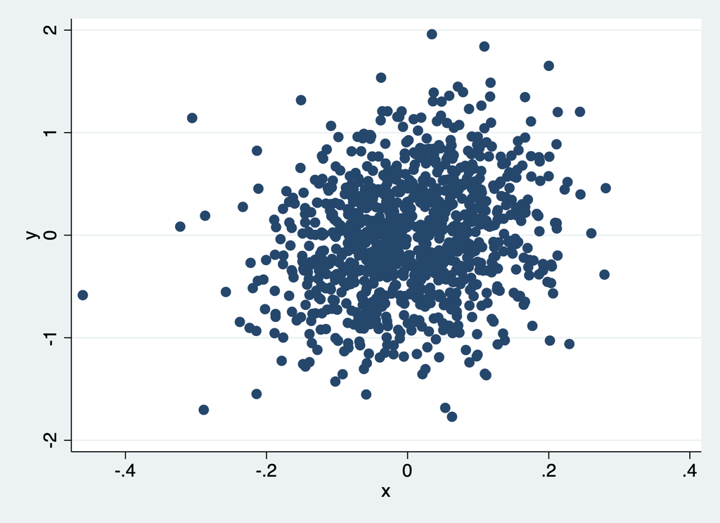

Scatter plot

```stata
. // scatter plot
. twoway scatter y x

. graph export "scatter.png", replace
(file scatter.png written in PNG format)
```

A great recent package tackles this problem by grouping data before plotting. The package is called *binscatter* and here is what it looks like with the same data:

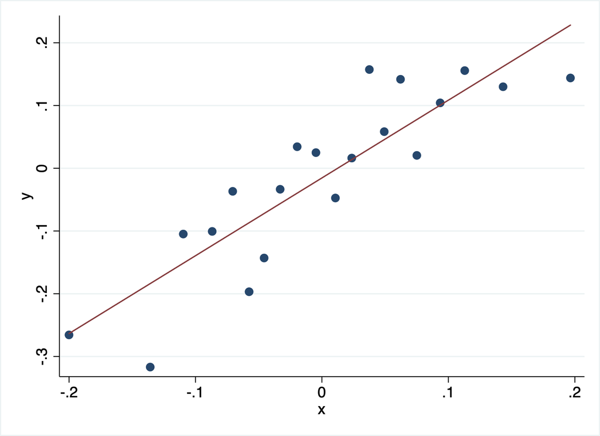

Binned scatter plot

```stata
. // binned scatter plot
. binscatter y x

. graph export "binscatter.png", replace
(file binscatter.png written in PNG format)
```

You will need to install it using command `ssc install binscatter` before using it.

## 3. Storing estimates

Oftentimes we would like to estimate something, then use that estimate in a later command.

One approach is to inspect the output and write it down directly:

```stata
. sum x

    Variable │        Obs        Mean    Std. Dev.       Min        Max
─────────────┼─────────────────────────────────────────────────────────
           x │      1,000    .0020498    .0971957  -.4604602   .2807839

. gen x_above_mean = 0

. replace x_above_mean = 1 if  x >= .002
(502 real changes made)
```

This works, but is likely to lead to errors and will be incorrect if your data changes.

A better approach is to store the estimate then retrieve it as follows:

```stata
. sum x

    Variable │        Obs        Mean    Std. Dev.       Min        Max
─────────────┼─────────────────────────────────────────────────────────
           x │      1,000    .0020498    .0971957  -.4604602   .2807839

. drop x_above_mean

. gen x_above_mean = 0

. replace x_above_mean = 1 if x >= r(mean)
(502 real changes made)
```

How did I know the mean was stored as `r(mean)`? I consulted the documentation for the `summarize` command by typing `help summarize`:

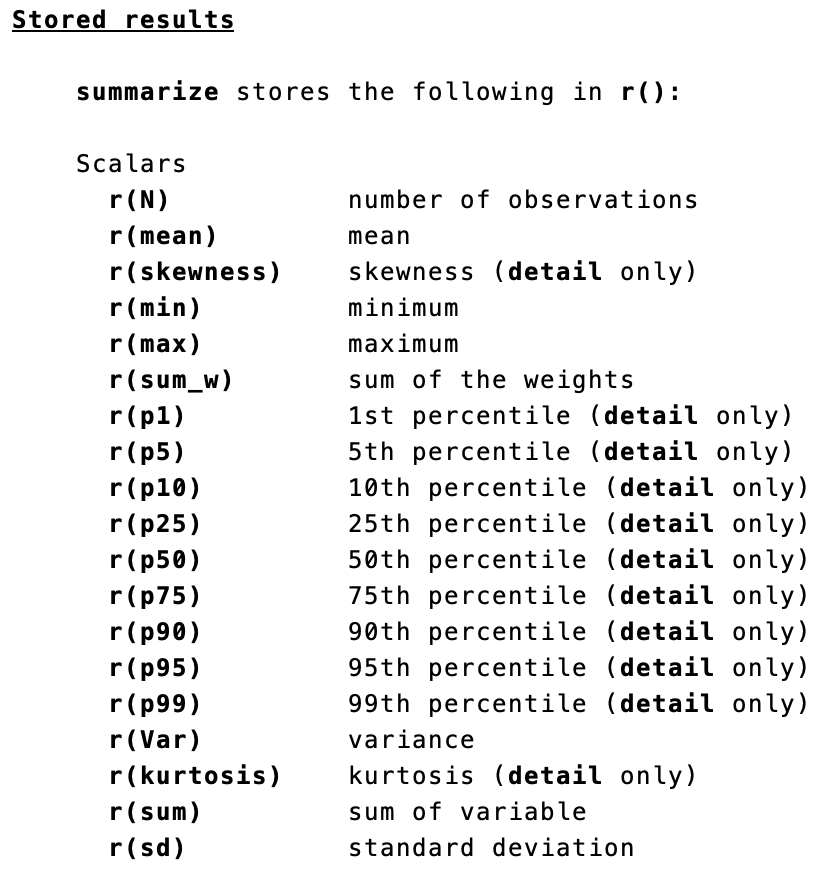

Stored results after `summarize`

In general, *hard-coding numbers into code is a bad idea*.

## 4. Making publication-quality graphs

Stata graphs are ugly by default:

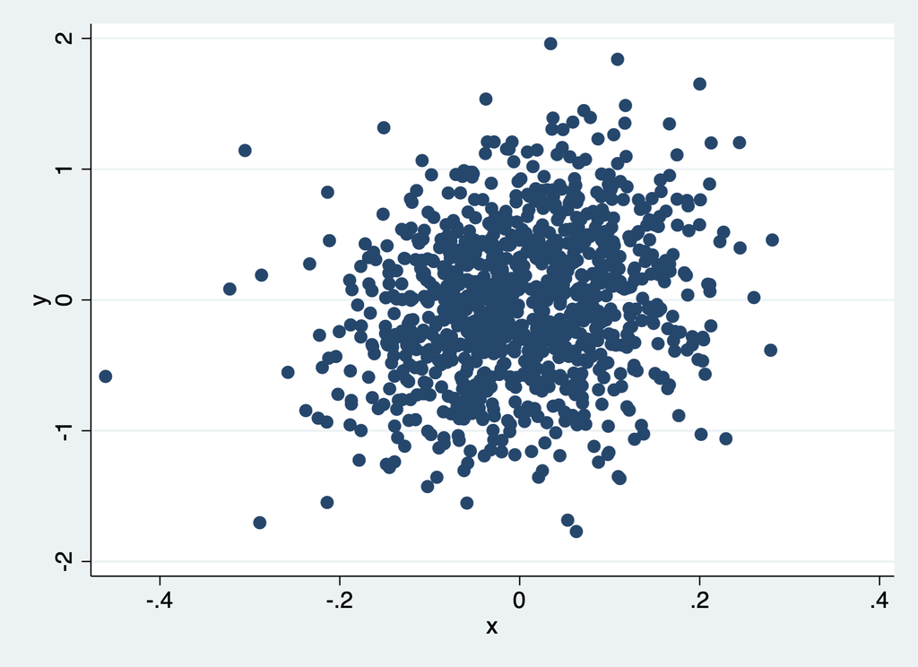

Ugly scatter plot

By adding some additional options, we can make much nicer looking graphs ready for presentations / publication:

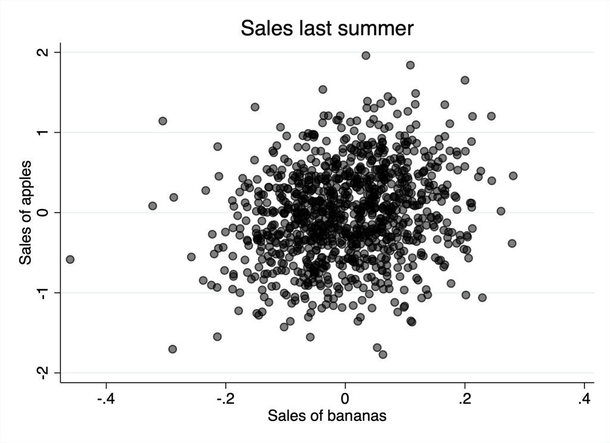

Nice-looking scatter plot

```stata
. // scatter plot
. twoway scatter y x, graphregion(color("white"))  mcolor(black%50) ///
> xtitle("Sales of bananas") ytitle("Sales of apples") ///
> title("Sales last summer", color("black"))

. graph export "scatterclean.png", replace
(file scatterclean.png written in PNG format)
```